# Hard_Skill_Test

```python
from google.colab import drive
drive.mount('/content/drive')
```

```python
import pandas as pd
import matplotlib.pyplot as plt
pixel = 1/plt.rcParams['figure.dpi']
import seaborn as sns
sns.set(color_codes=True)
import numpy as np
from sklearn import preprocessing
```

```python
from keras.wrappers.scikit_learn import KerasClassifier, KerasRegressor
import eli5
from eli5.sklearn import PermutationImportance
```

```python
from numpy.random import seed
from tensorflow.random import set_seed
from tensorflow.keras.layers import Dense
from tensorflow.keras.models import Sequential
from tensorflow.keras import regularizers
```

```python
df = pd.read_excel('/content/drive/My Drive/Colab Notebooks/O&G Equipment Data.xlsx')
```

# 1 - Calculate how many times the equipment has failed

```python
num_fails, first, num_fails_vector = 0, True, []
for i in df.Fail:
    if i and first:
        num_fails = num_fails +1
        first = False
    if not i: first = True
    num_fails_vector.append(num_fails)
df['Fail Counter'] = pd.Series(num_fails_vector)
```

## From the above code, it will add a new feature for the dataframe called 'Fail Counter' to count the periods of sequencial failure

```python
df.Fail.value_counts()
```

```
False    734
True      66
Name: Fail, dtype: int64
```

## As we can seen above, from the 800 cycles, there are 66 labeled as 'True' for feature 'Fail'

```python
df
```

|  | Cycle | Preset_1 | Preset_2 | Temperature | Pressure | VibrationX | VibrationY | VibrationZ | Frequency | Fail | Fail Counter |
| --- | --- | --- | --- | --- | --- | --- | --- | --- | --- | --- | --- |
| 0 | 1 | 3 | 6 | 44.235186 | 47.657254 | 46.441769 | 64.820327 | 66.454520 | 44.483250 | False | 0 |
| 1 | 2 | 2 | 4 | 60.807234 | 63.172076 | 62.005951 | 80.714431 | 81.246405 | 60.228715 | False | 0 |
| 2 | 3 | 2 | 1 | 79.027536 | 83.032190 | 82.642110 | 98.254386 | 98.785196 | 80.993479 | False | 0 |
| 3 | 4 | 2 | 3 | 79.716242 | 100.508634 | 122.362321 | 121.363429 | 118.652538 | 80.315567 | False | 0 |
| 4 | 5 | 2 | 5 | 39.989054 | 51.764833 | 42.514302 | 61.037910 | 50.716469 | 64.245166 | False | 0 |
| ... | ... | ... | ... | ... | ... | ... | ... | ... | ... | ... | ... |
| 795 | 796 | 2 | 6 | 50.469522 | 98.235421 | 151.585252 | 99.341380 | 148.838481 | 49.841400 | True | 10 |
| 796 | 797 | 1 | 4 | 49.985270 | 160.433640 | 110.953010 | 160.777175 | 109.917566 | 110.919290 | True | 10 |
| 797 | 798 | 1 | 4 | 79.777294 | 110.535405 | 61.334995 | 149.577811 | 129.463843 | 70.853353 | True | 10 |
| 798 | 799 | 2 | 8 | 79.360314 | 159.985443 | 61.762879 | 169.773831 | 130.213426 | 80.113540 | True | 10 |
| 799 | 800 | 3 | 1 | 80.854011 | 110.543701 | 121.032227 | 131.719473 | 90.331155 | 71.261717 | True | 10 |

800 rows × 11 columns

## Also, from the new feature 'Fail Counter', there are 10 periods of sequencial cycles labeled as True for feature 'Fail'. Therefore, it means the system failed 10 times with 66 cycles labeled as failed

# 2 - Categorize equipment failures by setups configurations

```python
df_Fail = df[df.Fail==True]
```

```python
df_Fail = df_Fail.set_index('Cycle')
```

## Above, it was created a new dataframe called df_Fail exclusively with failure events indexed by their cycle

```python
df_Fail['Setup_Configuration'] = None
```

```python
for i in df_Fail.index:
    df_Fail['Setup_Configuration'][i] = str(df_Fail['Preset_1'][i])+', '+str(df_Fail['Preset_2'][i])
```

## Then, it was created a new feature for df_Fail which for each cycle it combines features from 'Present_1' and 'Present_2', its counting is shown below

```python
df_Fail.Setup_Configuration.value_counts()
```

```
1, 2    5
1, 5    5
2, 8    4
1, 7    4
3, 5    4
2, 1    4
1, 1    4
1, 6    3
3, 7    3
2, 6    3
2, 5    3
3, 6    3
3, 1    3
1, 3    2
1, 8    2
2, 2    2
2, 7    2
3, 2    2
2, 3    2
3, 3    2
1, 4    2
3, 8    1
2, 4    1
Name: Setup_Configuration, dtype: int64
```

# 3 - Categorize equipment failures by their nature/root cause according to parameter readings (temperature, pressure, and others)

## Generally in maintenance engineering, in this case, data scientists try to detect anomalies from a given dataset. In fact, it means trying to find data that don't behaves as a desired pattern, the outliers. Therefore, outlier detection can be done using statistical methods or using a data science approach. For example, as seen below, box-plot is a famous method to detect from outliers using quartile property.

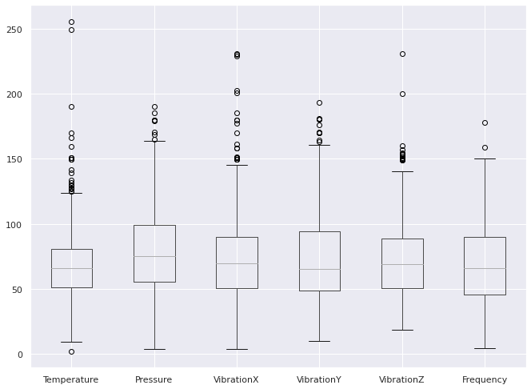

```python
df[df.columns[3:9]].boxplot(figsize=(800*pixel, 600*pixel))
plt.show()
```

## Then, after using a visual approach, it is possible to classify each feature as an outlier by using a threshold of third quartile plus 1.5 interquartile.

```python
def check_outliers(k = 1.5):
    stats_parameters = df[df.columns[3:9]].describe()
    upper_dict = {}
    for column in stats_parameters.columns:
        IQR = stats_parameters[column]['75%']-stats_parameters[column]['25%']
        upper_dict[column] = stats_parameters[column]['75%'] + k*(IQR)

    stats_parameters = stats_parameters.append(pd.Series(data=upper_dict, name ='upper extreme'))
    display(stats_parameters)


    columns = df.columns[3:9]
    for column in columns:
        outlier_class = {}
        for i in df_Fail[column].index:
            if df_Fail[column][i] <= stats_parameters[column]['25%']: outlier_class[i] = 'Q1'
            if df_Fail[column][i] > stats_parameters[column]['25%'] and df_Fail[column][i] <= stats_parameters[column]['50%']: outlier_class[i] = 'Q2'
            if df_Fail[column][i] > stats_parameters[column]['50%'] and df_Fail[column][i] <= stats_parameters[column]['75%']: outlier_class[i] = 'Q3'
            if df_Fail[column][i] > stats_parameters[column]['75%'] and df_Fail[column][i] <= stats_parameters[column]['upper extreme']: outlier_class[i] = 'Q4'
            if df_Fail[column][i] > stats_parameters[column]['upper extreme']: outlier_class[i] = 'outlier'
        outlier_series = pd.Series(data=outlier_class, name =column+'_outlier')
        outlier_series.index = outlier_series.index.set_names('Cycle')

        df_Fail[column+'_outlier'] = outlier_series

    df_Fail['Nature/Root'] = None
    for i in df_Fail.index:
        root = ''
        if df_Fail['Temperature_outlier'][i] == 'outlier': root = root+'Temperature '
        if df_Fail['Pressure_outlier'][i] == 'outlier': root = root+'Pressure '
        if df_Fail['VibrationX_outlier'][i] == 'outlier': root = root+'VibrationX '
        if df_Fail['VibrationY_outlier'][i] == 'outlier': root = root+'VibrationY '
        if df_Fail['VibrationZ_outlier'][i] == 'outlier': root = root+'VibrationZ '
        if df_Fail['Frequency_outlier'][i] == 'outlier': root = root+'Frequency '
        df_Fail['Nature/Root'][i] = root
        if df_Fail['Nature/Root'][i] == '': df_Fail['Nature/Root'][i] = 'Unkown'

    display(df_Fail['Nature/Root'].value_counts())
```

## From the result below, the majority of the failures has unknown nature/root. Which means that a further investigation is demanded. For example, combining features to check its behavior (e.g. VibrationZ divided by Frequency), transforming features (e.g. squared root of Temperature) and finally trying different outlier detection methods: distance-based, clustering, classification techniques

```python
check_outliers()
```

|  | Temperature | Pressure | VibrationX | VibrationY | VibrationZ | Frequency |
| --- | --- | --- | --- | --- | --- | --- |
| count | 800.000000 | 800.000000 | 800.000000 | 800.000000 | 800.000000 | 800.000000 |
| mean | 69.263494 | 78.997945 | 73.860275 | 72.786878 | 71.866211 | 68.223449 |
| std | 25.536252 | 32.501834 | 31.229631 | 32.739745 | 27.844616 | 29.138702 |
| min | 2.089354 | 3.480279 | 3.846343 | 10.057744 | 18.784169 | 4.380101 |
| 25% | 51.040134 | 55.508564 | 50.752461 | 48.523982 | 50.787638 | 45.861762 |
| 50% | 65.906716 | 75.014848 | 69.394953 | 65.504770 | 69.319237 | 65.664252 |
| 75% | 80.527220 | 99.302530 | 90.195059 | 94.075572 | 88.891205 | 90.097457 |
| max | 255.607829 | 189.995681 | 230.861142 | 193.569947 | 230.951134 | 178.090303 |
| upper extreme | 124.757848 | 164.993478 | 149.358956 | 162.402958 | 146.046555 | 156.450999 |

```
Unkown                     44
Temperature                 4
VibrationZ                  4
VibrationX VibrationZ       3
Pressure                    2
VibrationY                  2
Pressure VibrationY         2
Temperature VibrationY      1
VibrationY VibrationZ       1
Pressure VibrationX         1
VibrationX                  1
Frequency                   1
Name: Nature/Root, dtype: int64
```

# 4 – Create a model using the technique you think is most appropriate and measure its performance

```python
counters = df['Fail Counter'].unique()
counter = counters[0]
for counter in counters:
    if counter < counters[-1]:
        len_train = df[df['Fail Counter']==counter & (df['Fail']==False)].shape[0]
        len_test = df[(df['Fail Counter']==counter+1) & (df['Fail']==True)].shape[0]
        print('Fail Counter', counter)
        print('Total length', len_train+len_test)
        print('Train',round(len_train/(len_train+len_test)*100,2))
        print('Test',round(len_test/(len_train+len_test)*100,2))
        #print(len_test/(len_train+len_test)))
        print('\t')
```

```
Fail Counter 0
Total length 13
Train 92.31
Test 7.69

Fail Counter 1
Total length 146
Train 97.95
Test 2.05

Fail Counter 2
Total length 15
Train 80.0
Test 20.0

Fail Counter 3
Total length 146
Train 97.95
Test 2.05

Fail Counter 4
Total length 14
Train 85.71
Test 14.29

Fail Counter 5
Total length 161
Train 88.82
Test 11.18

Fail Counter 6
Total length 21
Train 57.14
Test 42.86

Fail Counter 7
Total length 148
Train 96.62
Test 3.38

Fail Counter 8
Total length 26
Train 46.15
Test 53.85

Fail Counter 9
Total length 151
Train 94.7
Test 5.3
```

```python
counter = 5
```

## Plotting of train database

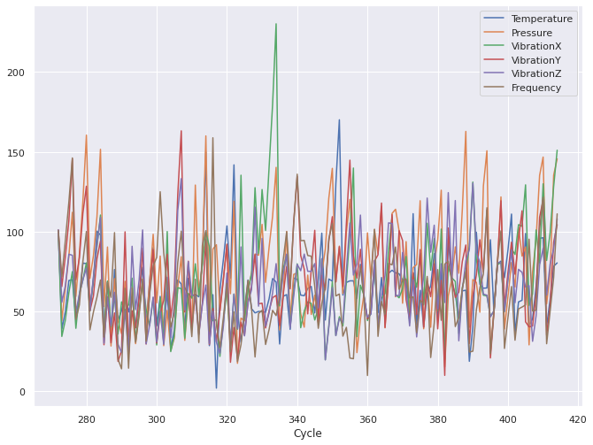

```python
X_train = df[(df['Fail Counter']==counter) & (df['Fail']==False)]
X_train = X_train.set_index('Cycle')
X_train = X_train[df.columns[3:9]]
X_train.plot(figsize=(800*pixel, 600*pixel))
plt.show()
```

## Plotting of test database

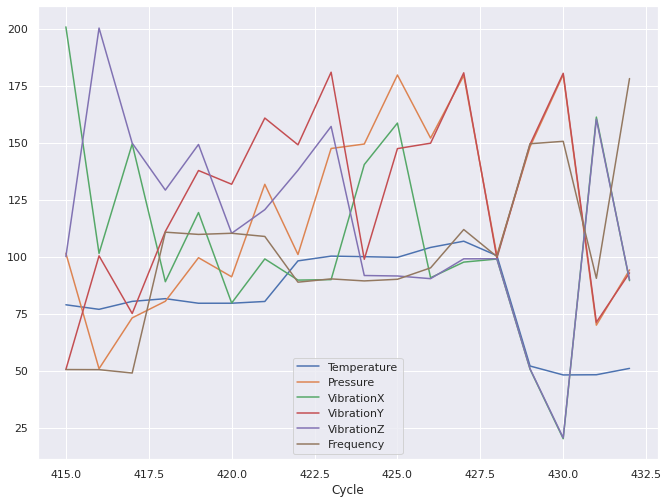

```python
X_test = df[(df['Fail Counter']==counter+1) & (df['Fail']==True)]
X_test = X_test.set_index('Cycle')
X_test = X_test[df.columns[3:9]]
X_test.plot(figsize=(800*pixel, 600*pixel))
plt.show()
```

## In order to detect anomaly, it is used an Autoencoder model, using a 3 layer neural network with 10-2-10 nodes. Then, it is used softplus as activattion function, mean absolute error as loss function, and train the model using the Adam optimizer.

```python
seed(10)
set_seed(10)
act_func = 'softplus'
loss_func = 'mae'
opt_func = 'adam'

model=Sequential()

model.add(Dense(10,activation=act_func,
                kernel_initializer='glorot_uniform',
                kernel_regularizer=regularizers.l2(0.0),
                input_shape=(X_train.shape[1],)
               )
         )

model.add(Dense(2,activation=act_func,
                kernel_initializer='glorot_uniform'))

model.add(Dense(10,activation=act_func,
                kernel_initializer='glorot_uniform'))

model.add(Dense(X_train.shape[1],
                kernel_initializer='glorot_uniform'))

model.compile(loss=loss_func,optimizer=opt_func)

NUM_EPOCHS=400
BATCH_SIZE=5
```

## Also, it is used 400 epochs with a batch size of 5. Then, it is used 5% of the training data to validate each epoch.

```python
history=model.fit(np.array(X_train),np.array(X_train),
                  batch_size=BATCH_SIZE,
                  epochs=NUM_EPOCHS,
                  validation_split=0.05,
                  verbose = 1)
```

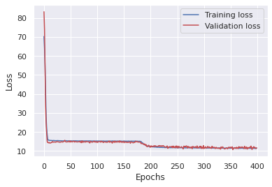

```python
plt.plot(history.history['loss'],
         'b',
         label='Training loss')
plt.plot(history.history['val_loss'],
         'r',
         label='Validation loss')

plt.legend(loc='upper right')
plt.xlabel('Epochs')
plt.ylabel('Loss')
plt.show()
```

## Then, with the distribution plot of the training set's calculated loss, it is possible to identify a threshold to detect anomalies, which means finding a value above the "noise level", and the detected anomalies should have a statistical significancy and rely above the "noise background"

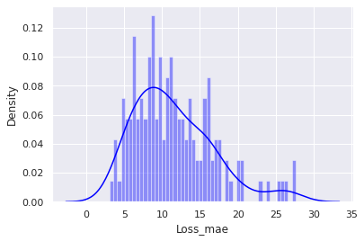

```python
X_pred = model.predict(np.array(X_train))
X_pred = pd.DataFrame(X_pred,
                      columns=X_train.columns)
X_pred.index = X_train.index

scored = pd.DataFrame(index=X_train.index)
scored['Loss_mae'] = np.mean(np.abs(X_pred-X_train), axis = 1)
plt.figure()
sns.distplot(scored['Loss_mae'],
             bins = 50,
             kde= True,
             color = 'blue')
```

## Analyzing the the above loss distribution, a threshold of 30 to detected anomaly fits like a good value. Then, it is possible to calculate the loss in the test set to check if it crosses the threshold

```python
Threshold = 30
```

```python
X_pred = model.predict(np.array(X_test))
X_pred = pd.DataFrame(X_pred,
                      columns=X_test.columns)
X_pred.index = X_test.index

scored = pd.DataFrame(index=X_test.index)
scored['Loss_mae'] = np.mean(np.abs(X_pred-X_test), axis = 1)
scored['Threshold'] = Threshold
scored['Anomaly'] = scored['Loss_mae'] > scored['Threshold']
scored.head()
```

| Cycle | Loss_mae | Threshold | Anomaly |
| --- | --- | --- | --- |
| 415 | 17.237692 | 30 | False |
| 416 | 50.760724 | 30 | True |
| 417 | 19.502050 | 30 | False |
| 418 | 17.257111 | 30 | False |
| 419 | 22.062964 | 30 | False |

## Then, it is possible to do the same for the train test

```python
X_pred_train = model.predict(np.array(X_train))
X_pred_train = pd.DataFrame(X_pred_train,
                            columns=X_train.columns)

X_pred_train.index = X_train.index
scored_train = pd.DataFrame(index=X_train.index)
scored_train['Loss_mae'] = np.mean(np.abs(X_pred_train-X_train),axis = 1)
scored_train['Threshold'] = Threshold
scored_train['Anomaly'] = scored_train['Loss_mae'] > scored_train['Threshold']

scored = pd.concat([scored_train, scored])
```

## Finally, the entire plotting

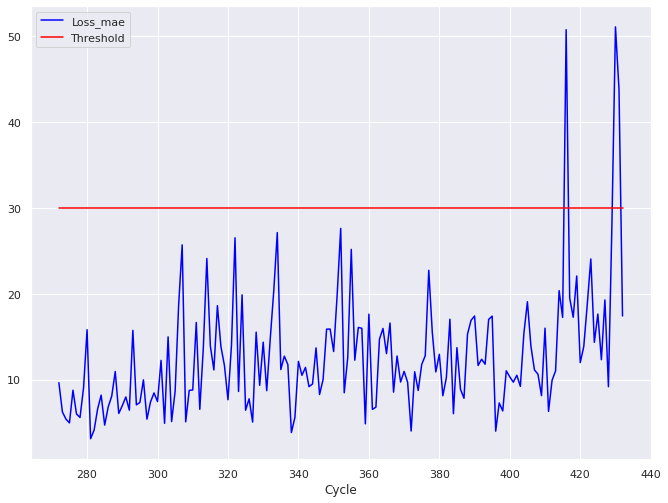

```python
scored.plot(figsize = (800*pixel,600*pixel), color = ['blue','red'])
plt.show()
```

## In order to check false positives, false negatives, true positives, and true negatives. It is build a confusion matrix

```python
Anomaly = scored.Anomaly
Fail = df[((df['Fail Counter']==counter+1) & (df['Fail']==True)) |
          ((df['Fail Counter']==counter) & (df['Fail']==False))].set_index('Cycle').Fail
```

```python
df_confusion = pd.crosstab(Fail, Anomaly)
df_confusion
```

| Anomaly Fail | False | True |
| --- | --- | --- |
| False | 143 | 0 |
| True | 15 | 3 |

## In order to measure a good balance between precision and recall, it is calculated the F1 score.

```python
TP = df_confusion[True][True]
FP = df_confusion[True][False]
TN = df_confusion[False][False]
FN = df_confusion[False][True]

confusion_matrix_accuracy = (TP + TN)/(TP + TN + FP + FN)
confusion_matrix_precision = TP/(TP + FP)
confusion_matrix_recall = TP/(TP + FN)

f1_score = 2*confusion_matrix_precision*confusion_matrix_recall/(confusion_matrix_precision + confusion_matrix_recall)
print(f1_score)
```

```
0.2857142857142857
```

## Since F1 score ranges between 0 and 1, it did not performed very well. A further investigation must be done with different techniques, such as suport vector machine, Mahalanobis distance, fuzzy logic, bayesian networks and others.

# 5 – Analyze variable importance

## As seen below, the results show that the most important variables are Frequency, VibrationX, VibrationY. And the less important are VibrationZ, Temperature, Pressure.

```python
perm = PermutationImportance(model, scoring = 'neg_median_absolute_error', random_state=1).fit(np.array(X_train),np.array(X_train))
eli5.show_weights(perm, feature_names = X_train.columns.tolist())
```

| Weight | Feature |
| --- | --- |
| 4.6245 ± 0.9504 | Frequency |
| 3.3824 ± 0.7625 | VibrationX |
| 1.6933 ± 0.4158 | VibrationY |
| 1.3131 ± 0.3984 | Pressure |
| 0.6995 ± 0.2524 | Temperature |
| 0.5841 ± 0.4659 | VibrationZ |